# Distributions

Last updated: 2017-01-24

## Notes

## Readings

## Distributions most commonly encountered

1. Frequency distribution
   - Shows the number of times each measurement occurs in a sample (possibly "binned")
2. Probability distribution:
   - A probability distribution shows the probability that measurement occurs in a sample.
   - Usually based on the observed data

## Frequency distributions

```r
# Set the seed for the random number generator
set.seed(5)

# Random numbers with a mean of 0 and standard deviation of 1
x <- rnorm(200)
M <- data_frame(x)  # Make a data_frame for ggplot
```

## Histograms: Visualizing frequency distributions

```r
ggplot(M, aes(x = x)) +
  geom_histogram()
```

Use the `x` column from `M` to make a histogram.

## Histograms: Visualizing frequency distributions

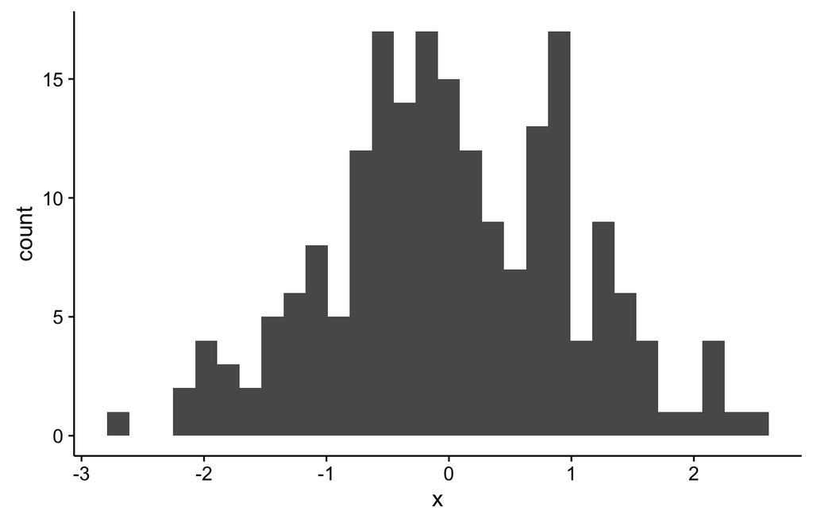

## Density plots: Visualizing probability distributions

```r
ggplot(M, aes(x = x)) +
  geom_density()
```

Note `geom_density()` here instead of `geom_histogram()`. ggplot makes it easy to switch between different kinds of visualizations of the data.

## Density plots: Visualizing probability distributions

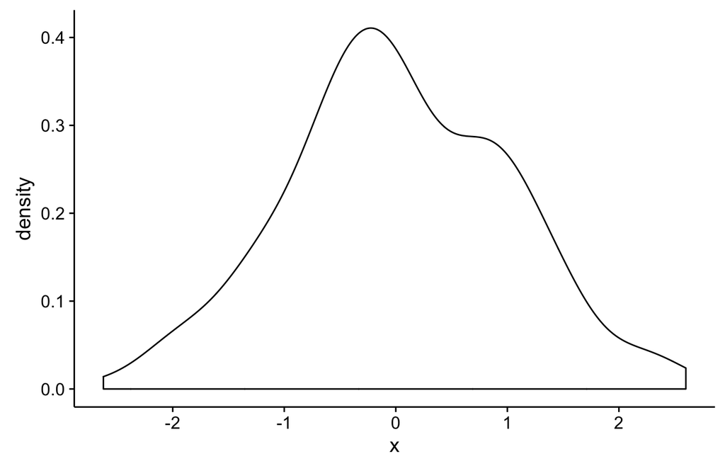

## Frequency vs. probability distribution

A frequency distribution has an underlying probability distribution.

```r
ggplot(M, aes(x = x)) +
  geom_histogram(aes(y = ..density..), fill = "gray") +
  geom_density()
```

- `..density..` is needed to get the y scale correct. You don't need to understand why.

## Frequency vs. probability distribution

A frequency distribution has an underlying probability distribution.

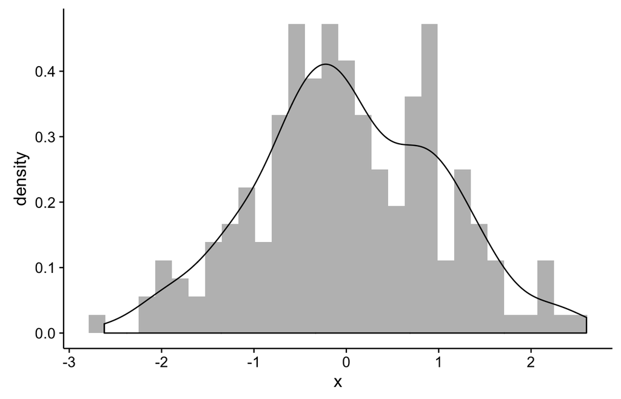

## Frequency vs. probability distribution

Generate the actual probability for \(\mu = 0\) and \(\sigma = 1\) using the normal distribution's probability density function.

\[ f\left(Y\right)=\frac{1}{\sqrt{2\pi\sigma^{2}}}e^{\frac{-\left(Y-\mu\right)^{2}}{2\sigma^{2}}} \]

> "There is no avoiding mathematics when doing data analysis." (Kruschke 2015)

## Frequency vs. probability distribution

Write a function to return the probability of an observation \(Y\) for a given population mean (\(\mu\)) and standard deviation (\(\sigma\)):

```r
normal <- function(Y, mu = 0, sigma = 1){
  1 / sqrt(2 * pi * sigma ^ 2) *
    exp((-(Y - mu) ^ 2 / (2 * sigma ^ 2)))
}
```

Calculate the probability for a range of \(Y\) from -3 to 3.

```r
Y <- seq(-3, 3, length = 200)
prob <- normal(Y)
M_prob <- data_frame(Y, prob)
```

## Frequency vs. probability distribution

```r
ggplot(M, aes(x = x)) +
  geom_histogram(aes(y = ..density..), fill = "gray") +
  geom_line(data = M_prob, aes(x = Y, y = prob))
```

Note:

- Main data comes from `M`, `..density..` to get y scale correct
- New `data = M_prob` in `geom_line()`. Then use `Y` and `prob` for drawing the line.

## Frequency vs. probability distribution

[figure not shown]

\(n = 200\) here. What about \(n = 2000\)? \(n = 200000\)?

## Shapes of distributions

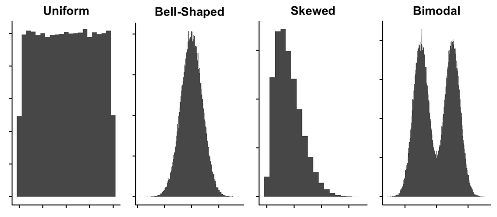

Bimodal distributions are particularly challenging for analysis.

## References

Kruschke, J. K. 2015. *Doing Bayesian Data Analysis: A Tutorial with R, JAGS, and Stan*. Academic Press, Boston, MA.